# 14.4.4-14.4.6

이번 단원은 역사적으로 컴퓨터 비전 분야의 알고리즘에는 이러한 것들이 있었다 정도로 이해하시고 넘어가시는게 좋을 듯 합니다.

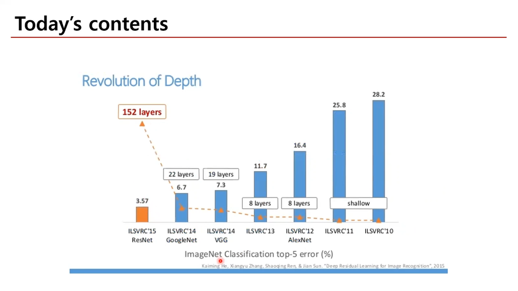

## 14.4.4 VGGNet

- ILSVRC(ImageNet Large Scale Visual Recognition Challenge) 2014 대회에서 준우승한 옥스퍼드대 VGG 연구소의 캐런 시몬얀, 앤드루 지서만이 개발
- 단순하고 고전적인 구조
- 2개 또는 3개의 합성곱 층 뒤에 풀링 층이 나오고 다시 2개 또는 3개의 합성곱 층과 풀링 층이 등장하는 형식(종류에 따라 16개 또는 19개의 합성곱 층이 있음)
- 마지막 밀집 네트워크는 2개의 은닉층과 출력층으로 이루어짐
- VGGNet은 많은 개수의 필터를 사용하는데 3x3 필터만 사용한다.

## 14.4.5 ResNet

- 카이밍 허 등은 잔차 네트워크(또는 ResNet) 을 사용해 이미지넷 2015 대회에서 우승.
- 우승시 152개 층으로 구성된 극도로 깊은 CNN 사용
- 더 적은 파라미터를 사용해 점점 더 깊은 네트워크로 모델을 구성하는 일반적인 트랜드를 만듦
- 깊은 네트워크로 훈련시킬 수 있었던 핵심요소는 스킵 연결(숏컷 연결)이다.
- 스킵 연결: 어떤 층에 주입되는 신호가 상위 층의 출력에 더해지는 것을 말한다.
- 잔차 학습: 신경망 훈련 시 h(x)를 모델링하는 것이 목표인데, 만약 입력 x를 네트워크의 출력에 더한다면(스킵 연결을 추가하면) 네트워크는 h(x) 대신 f(x) = h(x) - x 를 학습하게 되고 이를 잔차 학습이라 한다.

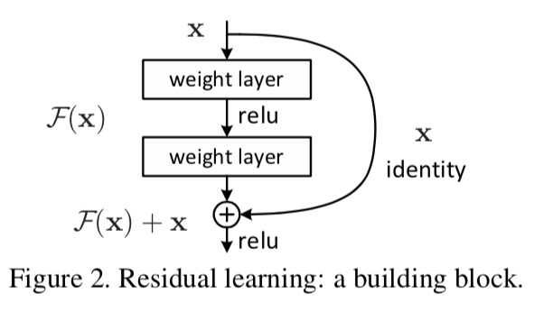

f(x) ==> h(x) 가 되도록 학습해야하는데(일반적 신경망)

f(x) + x ==> h(x) 가 되도록 학습시킨다면

f(x) ==> h(x) - x 를 학습하게 된다.

- 일반적인 신경망의 가중치는 0에 가깝기 때문에 네트워크도 0에 가까운 값을 출력한다.
- 스킵연결을 추가하면 x+(0에 가까운 값) 을 출력하게 된다(항등함수를 학습하게 되는 셈)
- 목적함수가 항등함수에 매우 가깝다면 훈련속도가 매우 빨라진다.
- 스킵연결을 많이 추가하면 일부 층이 아직 학습되지 않았더라도 네트워크는 훈련을 시작할 수 있다.
- 스킵 연결덕분에 입력신호가 전체 네트워크에 손쉽게 영향을 미친다.
- 심층 잔차 네트워크는 스킵 연결을 가진 작은 신경망인 잔차 유닛을 쌓은 것으로 볼 수 있다.

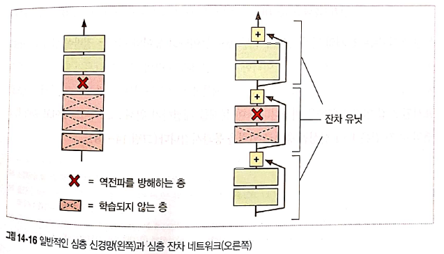

ResNet 구조를 살펴보면 다음과 같다

- GoogleNet과 똑같이 시작하고 종료하는데, 중간에 잔치유닛이 매우 깊게 쌓여있다.
- 각 잔차 유닛은 배치 정규화와 ReLU, 3x3 커널을 사용한다.
- 공간정보를 유지하는 (스트라이드1, "same" 패딩) 두 개의 합성곱 층(풀링 없음)으로 이루어져 있다.

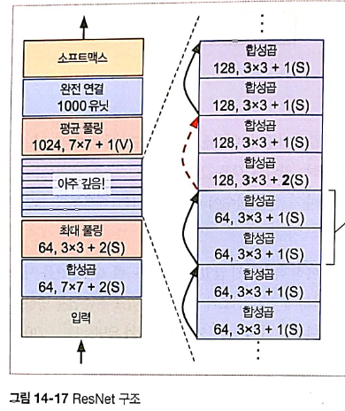

571쪽은 무슨 말인지 잘 모르겠습니다.. 아마도 위에 나왔던 내용보다 조금 더 복잡하고 깊은 ResNet을 말하는 것 같습니다.

## 14.4.6 Xception

- 케라스의 창시자 프랑수아 숄레가 2016년 제안
- 대규모 비전 문제에서 Inception-v3 보다 뛰어난 성능을 보임
- Inception-v4 와 마찬가지로 GoogleNet과 ResNet의 아이디어를 합침
- Inception과의 차이점은 깊이별 분리 합성곱 층이라는 특별한 층을 사용하여 파라미터수는 유지하면서 높은 성능을 보임.